# Machine Learning Project

Bento Collares

Friday, October 24, 2014

## Loading data

#### First we set the workspace to be the folder wih the downloaded data set and load the required packages

```r
setwd("C:/R workspace/machine learning")
pml_train = read.csv("pml-training.csv")
pml_test = read.csv("pml-testing.csv")
```

```r
library(caret)
```

#### Then we split the training pml_train data into a testing set and a training set.

#### Since the pml_train data set is large, we’ll set “p” to be 0.9.

```r
set.seed(1323)
inTrain = createDataPartition(pml_train$classe, p = 0.9, list = FALSE)
training = pml_train[inTrain,]
testing = pml_train[-inTrain,]
```

## Exploratory analysis and pre-Processing

#### The next obvious step is choosing a viable number of variables to fit the prediction model.

#### We start by removing the columns with no measurements (related to time or user name).

```r
names(training)

training = training[,-1:-7]
testing = testing[,-1:-7]
```

#### Then we remove columns with “NA” values and empty space values.

```r
toBeRemoved = c()
for(i in 1:dim(training)[2]){
    if( anyNA(training[,i])){
        toBeRemoved = c(toBeRemoved, i)
    }
    else if(training[1,i] == ""){
        toBeRemoved = c(toBeRemoved, i)
    }

}


training = training[, -toBeRemoved]
testing = testing[, -toBeRemoved]
```

#### Next we get a reasonable number of variables “n” and get the “n” variables with larger variance,

#### plus the class variable, which we will try to predict using the other variables.

```r
variance = sort(c(apply(training, 2, function(x) var(x, na.rm = TRUE))))
variables = tail(variance, 25)

training = training[,c(names(variables), "classe")]
testing = testing[,c(names(variables), "classe")]
```

## Model building

#### We will now fit a stochastic gradient boosting algorithm using those 25 variables build a

#### prediction model for “classe”.

#### The model with depth = 3 and 150 trees is superior to all others generated this way.

```r
set.seed(1323)
modFit = train(classe ~ ., data = training, method = "gbm", verbose = FALSE)
modFit
```

```
## Stochastic Gradient Boosting
##
## 17662 samples
##    25 predictor
##     5 classes: 'A', 'B', 'C', 'D', 'E'
##
## No pre-processing
## Resampling: Bootstrapped (25 reps)
##
## Summary of sample sizes: 17662, 17662, 17662, 17662, 17662, 17662, ...
##
## Resampling results across tuning parameters:
##
##   interaction.depth  n.trees  Accuracy  Kappa  Accuracy SD  Kappa SD
##   1                   50      0.7       0.6    0.009        0.011
##   1                  100      0.8       0.7    0.006        0.008
##   1                  150      0.8       0.7    0.005        0.006
##   2                   50      0.8       0.8    0.006        0.007
##   2                  100      0.9       0.8    0.004        0.005
##   2                  150      0.9       0.9    0.004        0.005
##   3                   50      0.9       0.8    0.005        0.006
##   3                  100      0.9       0.9    0.003        0.004
##   3                  150      0.9       0.9    0.003        0.004
##
## Tuning parameter 'shrinkage' was held constant at a value of 0.1
## Accuracy was used to select the optimal model using  the largest value.
## The final values used for the model were n.trees = 150,
##  interaction.depth = 3 and shrinkage = 0.1.
```

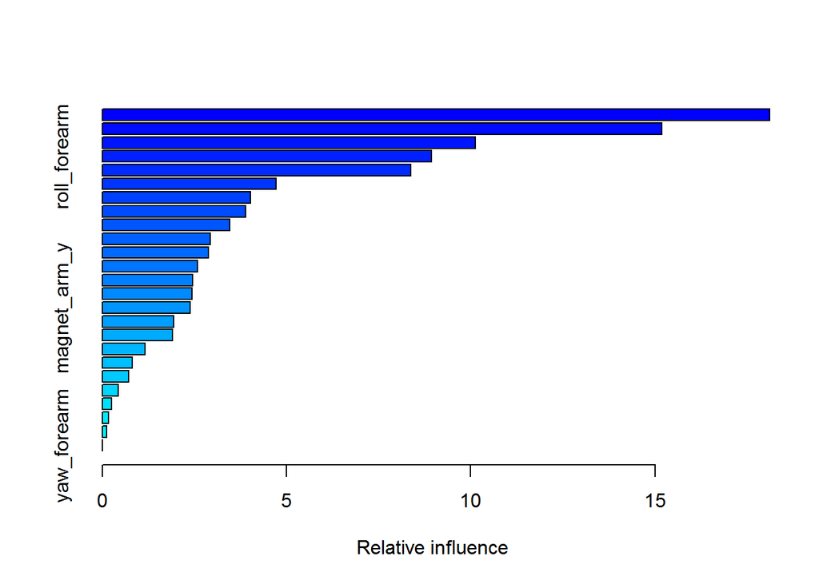

```
##                                 var rel.inf
## yaw_belt                   yaw_belt 18.1149
## accel_belt_z           accel_belt_z 15.1909
## magnet_dumbbell_z magnet_dumbbell_z 10.1347
## roll_forearm           roll_forearm  8.9297
## magnet_dumbbell_y magnet_dumbbell_y  8.3672
## accel_forearm_x     accel_forearm_x  4.7096
## accel_dumbbell_z   accel_dumbbell_z  4.0138
## roll_dumbbell         roll_dumbbell  3.8863
## magnet_forearm_z   magnet_forearm_z  3.4525
## accel_dumbbell_y   accel_dumbbell_y  2.9280
## magnet_dumbbell_x magnet_dumbbell_x  2.8881
## yaw_arm                     yaw_arm  2.5846
## magnet_arm_z           magnet_arm_z  2.4525
## magnet_arm_x           magnet_arm_x  2.4307
## magnet_arm_y           magnet_arm_y  2.3913
## magnet_forearm_x   magnet_forearm_x  1.9435
## accel_arm_x             accel_arm_x  1.9071
## roll_arm                   roll_arm  1.1677
## magnet_forearm_y   magnet_forearm_y  0.8163
## accel_forearm_z     accel_forearm_z  0.7202
## yaw_dumbbell           yaw_dumbbell  0.4390
## accel_forearm_y     accel_forearm_y  0.2507
## accel_arm_z             accel_arm_z  0.1602
## accel_arm_y             accel_arm_y  0.1204
## yaw_forearm             yaw_forearm  0.0000
```

```r
summary(modFit,n.trees=150)
```

#### Importance of variables is shown below.

#### From all 25 variables used, only one had no influence, indicating that 25 was a good guess.

```r
varImp(modFit, useModel = TRUE)
```

```
## gbm variable importance
##
##   only 20 most important variables shown (out of 25)
##
##                   Overall
## yaw_belt           100.00
## accel_belt_z        83.86
## magnet_dumbbell_z   55.95
## roll_forearm        49.29
## magnet_dumbbell_y   46.19
## accel_forearm_x     26.00
## accel_dumbbell_z    22.16
## roll_dumbbell       21.45
## magnet_forearm_z    19.06
## accel_dumbbell_y    16.16
## magnet_dumbbell_x   15.94
## yaw_arm             14.27
## magnet_arm_z        13.54
## magnet_arm_x        13.42
## magnet_arm_y        13.20
## magnet_forearm_x    10.73
## accel_arm_x         10.53
## roll_arm             6.45
## magnet_forearm_y     4.51
## accel_forearm_z      3.98
```

```r
modFit$finalModel
```

```
## A gradient boosted model with multinomial loss function.
## 150 iterations were performed.
## There were 25 predictors of which 24 had non-zero influence.
```

## Model performance

### In sample error

#### The model is very accurate, with about 95% accuracy and neglegible variance.Since the test set

#### is still sufficientely large, even with only 10% of the observations, I expect the out-of-sample

#### error to be similar to the in-sample error.

```r
performance <- predict(modFit,training)
confusionMatrix(performance, training$classe)
```

```
## Confusion Matrix and Statistics
##
##           Reference
## Prediction    A    B    C    D    E
##          A 4954  117    1    9    2
##          B   34 3170  120   16   56
##          C   18  102 2902  141   29
##          D   12   14   54 2724   49
##          E    4   15    3    5 3111
##
## Overall Statistics
##
##                Accuracy : 0.955
##                  95% CI : (0.951, 0.958)
##     No Information Rate : 0.284
##     P-Value [Acc > NIR] : <2e-16
##
##                   Kappa : 0.943
##  Mcnemar's Test P-Value : <2e-16
##
## Statistics by Class:
##
##                      Class: A Class: B Class: C Class: D Class: E
## Sensitivity             0.986    0.927    0.942    0.941    0.958
## Specificity             0.990    0.984    0.980    0.991    0.998
## Pos Pred Value          0.975    0.933    0.909    0.955    0.991
## Neg Pred Value          0.995    0.983    0.988    0.988    0.991
## Prevalence              0.284    0.194    0.174    0.164    0.184
## Detection Rate          0.280    0.179    0.164    0.154    0.176
## Detection Prevalence    0.288    0.192    0.181    0.162    0.178
## Balanced Accuracy       0.988    0.956    0.961    0.966    0.978
```

### Out of sample error

#### The model is accurate as well on the testing set cross validation, with about 94% accuracy and

#### a small variance, though much larger than the one found on the training set prediction.

```r
performance <- predict(modFit,testing)
confusionMatrix(performance, testing$classe)
```

```
## Confusion Matrix and Statistics
##
##           Reference
## Prediction   A   B   C   D   E
##          A 544  12   0   3   0
##          B   7 348  14   6   6
##          C   5  15 319  22   3
##          D   0   3   8 290   9
##          E   2   1   1   0 342
##
## Overall Statistics
##
##                Accuracy : 0.94
##                  95% CI : (0.929, 0.95)
##     No Information Rate : 0.285
##     P-Value [Acc > NIR] : < 2e-16
##
##                   Kappa : 0.924
##  Mcnemar's Test P-Value : 0.000336
##
## Statistics by Class:
##
##                      Class: A Class: B Class: C Class: D Class: E
## Sensitivity             0.975    0.918    0.933    0.903    0.950
## Specificity             0.989    0.979    0.972    0.988    0.998
## Pos Pred Value          0.973    0.913    0.876    0.935    0.988
## Neg Pred Value          0.990    0.980    0.986    0.981    0.989
## Prevalence              0.285    0.193    0.174    0.164    0.184
## Detection Rate          0.278    0.178    0.163    0.148    0.174
## Detection Prevalence    0.285    0.194    0.186    0.158    0.177
## Balanced Accuracy       0.982    0.949    0.952    0.946    0.974
```

## Prediction

```r
answers = as.character(predict(modFit, pml_test))

pml_write_files = function(x){
  n = length(x)
  for(i in 1:n){
    filename = paste0("problem_id_",i,".txt")
    write.table(x[i],file=filename,quote=FALSE,row.names=FALSE,col.names=FALSE)
  }
}

pml_write_files(answers)
```